# ECON20222: R Assessment - Prep Work, 2025/26

# Instructions

You should work through the code below and complete it. Keep the completed code and all the resulting output. Only once you completed this work you are in a position to answer the questions in the online quiz. Every student will see a slightly different collection of questions (as we will randomly draw 10 questions from a pool of questions).

The questions are of four types.

1. Questions that merely ask you to report output from your analysis.
2. Some questions will ask you about R code. For example, you will see a lot of gaps (`XXXX`) in the code and questions may ask you how to complete the code to make the code work. Sometimes the `XXXX` will represent one word and on other occasions it will represent a full line (or several) of code. Other questions may ask you about the output to be produced by a particular bit of code.
3. The third type of questions will test your understanding of econometric issues. For example: “What is the meaning of an estimated coefficient?” “Is a particular coefficient statistically significant?”
4. The fourth type of question, if asked, will be on general programming issues. For example: what is the meaning of a particular error message, or, how would you search for a particular piece of information.

# Introduction

The purpose of this exercise is to get an idea about the extend to which different countries are producing electricity from renewable sources (such as wind or solar).

We are using three datasets in this exercise.

1. Country-Year data on a number of energy indicators
2. Country level data on the physical size of a country
3. Country-year data on the degree of urbanisation

You should work through the code below and complete it. Keep the completed code and all the resulting output. Next you should answer the questions in the online quiz. Every student will see a slightly different collection of questions (as we will randomly draw 10 questions from a pool of questions).

The questions are of four types.

1. Questions that merely ask you to report output from your analysis.
2. Some questions will ask you about R code. For example, you will see a lot of gaps (`XXXX`) in the code and questions may ask you how to complete the code to make the code work. Sometimes the `XXXX` will represent one word and on other occasions it will represent a full line (or two) of code. Other questions may ask you about the output to be produced by a particular bit of code.
3. The third type of questions will test your understanding of econometric issues. For example: “What is the meaning of an estimated coefficient?” “Is a particular coefficient statistically significant?”
4. The fourth type of question, if asked, will be on general programming issues. For example: what is the meaning of a particular error message, or, how would you search for a particular piece of information.

# Preparing your workfile

We add the basic libraries needed for this week’s work:

```r
library(tidyverse)    # for almost all data handling tasks
library(ggplot2)      # to produce nice graphiscs
library(stargazer)    # to produce nice results tables
library(AER)          # access to HS robust standard errors
source("stargazer_HC.r")  # includes the robust regression display
```

# Data Upload - and understanding data structure

Let’s import the various datasets

## Energy information

**WarningTask 1: Upload Energy Data**

Upload the data, which are saved in the csv. Making sure that the path points to your file.

```r
en.data <- XXXX("owid-energy-data.csv")
names(XXXX)
```

```
  [1] "country"
  [2] "year"
  [3] "iso_code"
  [4] "population"
  [5] "gdp"
  [6] "biofuel_cons_change_pct"
  [7] "biofuel_cons_change_twh"
  [8] "biofuel_cons_per_capita"
  [9] "biofuel_consumption"
 [10] "biofuel_elec_per_capita"
 [11] "biofuel_electricity"
 [12] "biofuel_share_elec"
 [13] "biofuel_share_energy"
 [14] "carbon_intensity_elec"
 [15] "coal_cons_change_pct"
```

[output cut: 115 more lines]

You should have 23,232 rows and 130 variables. Look at the type of variables and the structure of the variable names.

**WarningTask 2: Understand the general data structure**

The following are the type of questions you should be able to answer

- What does one row of the data represent?
- How many different countries are there?
- How many different years of data are there?
- Are there only countries or other entities?

Explore the data so that you can answer these questions.

Let’s create a table that matches the existing `iso_codes` to country names.

```r
country.map <- en.data %>% filter(!is.na(iso_code)) %>%
                    select(country, iso_code) %>%
                    unique() %>%
                    arrange(country)
```

**WarningTask 3: Restrict dataset**

For what follows we will restrict the data to only the observations that have an `iso_code` (`!is.na(iso_code)`). Create such a restricted dataset and save it into a new dataframe called `en.data.r`.

If you have done that correctly you should have 17,134 rows of data. From now on we shall be working with `en.data.r`. As you can see from `country.map` the list of entities with `iso_code` contains countries, but also some territories like Greenland (GRL) which are not fully independent countries or are indeed disputed terretories. We will still call this variable `country` for simplicity.

Let’s create a Table that shows for how many entities we have population data in every year.

```r
table1 <- en.data.r %>% filter(!is.na(population)) %>%
            group_by(year) %>%
            summarise(n = n())

tail(table1)
```

```
# A tibble: 6 × 2
   year     n
  <dbl> <int>
1  2020   218
2  2021   218
3  2022   218
4  2023   218
5  2024   122
6  2025    35
```

By looking at the last few entries you can see that 2023 seems to be the last year with complete population data.

**WarningTask 4: Create summary table**

Create a similar table (and call it `table2`) that lists for how many years there are population data for each country.

The dataset is about how different countries generate energy and electricity. What different fuel types are captured in the dataset? A quick look at the variable names reveals that there are for sure “biofuel”, “coal”, “gas” etc.

**WarningTask 5: Understand Fuel sources**

Try and understand how many different fuel types are captured in the dataset.

Think about how you could confirm that the sources you identified are indeed all the sources in the dataset. Then implement your test and figure out what summary categories (like “fossil” are available and how they relate to each other)

Understand what the following line of code does. It may (but not necessarily) become useful in the process of verifying your selection.

```r
sel_vars_energy <- names(en.data.r)[grepl("share_energy", names(en.data.r))]
```

## Country characteristics

There are many factors which could influence the use of renewable electricity generation in a certain country. Here we will only look at a couple

1. The population density
2. The degree of urbanisation

Other obvious factors are those that relate to the climatic conditions which will have an important bearing on whether hydro, solar or wind generation are available options. For this work we will concentrate on the ones listed above.

To investigate the relationship of the above factors with the generation type we need information on

- population size (which is already included in `en.data`)
- the size of a country (so we can then clalculate the population density)
- the percentage of population living in urban areas

Let’s start with the import of the size of a country

```r
ls.data <- read.csv("landarea_km_OWID.csv")
head(ls.data)
```

```
               Entity Code Year Land.area..sq..km.
1         Afghanistan  AFG 2023             652230
2             Albania  ALB 2023              27400
3             Algeria  DZA 2023            2381740
4             Andorra  AND 2023                470
5              Angola  AGO 2023            1246700
6 Antigua and Barbuda  ATG 2023                440
```

You can see that here we have one row of information for every country, the land size in square kilometers. Importantly you can also find the same three letter iso country code we also have in the energy dataset. This is super useful as it allows us to easily merge this information into `en.data.r`.

**WarningTask 6: Merge `ls.data` into `en.data.r`**

Delete the `Entity` and `Year` variables from `ls.data`, rename the `Land.area..sq..km.` variable to `ls.skm` and then merge the land size variable into the `en.data.r` dataframe. Only keep the observations for which we do have land size data.

Your dataframe `en.data.r` should now have 15,735 rows and 131 variables.

**WarningTask 7: Calculate population density and GDP per capita**

Now we can calculate the Population density as we have the `population` and the `ls.sqm` information for countries. Calculate a `pop.den` variable which is calculated as `population/ls.sqm` and add this to `en.data.r`.

Also calculate the GDP per capita and save it in a new `gdp.pc` variable, noting that GDP is measured in US dollars.

You got this right if the mean values (ensuring to exclude NA values) for the new variables in `en.data.r` are 114.8585132 (for `pop.den`) and 10,262 (for `gdp.pc`).

We want to import the data on the percentage of population living in urban areas. Here we expect the data to vary by year for every country. The spreadsheet contains data from 1960 to 2024.

**WarningTask 8: Import, prepare and merge urbanisation data**

The data is in “urbanpop_WB.csv”. Import this and manipulate it such that you have a long dataset (name it `pd.data.long`) with the following structure (and 17,290 rows of data).

```
# A tibble: 6 × 3
  iso_code year  Urban.pc
  <chr>    <chr>    <dbl>
1 ABW      1960      59.0
2 ABW      1961      59.1
3 ABW      1962      59.2
4 ABW      1963      59.4
5 ABW      1964      59.7
6 ABW      1965      60.1
```

Now you should merge the `Urban.pc` variable into `en.data.r` only keeping the rows of data for which we do have data for `Urban.pc`.

In order to establish that you have worked correctly so far, replicate the following summary statistics:

```r
dim(en.data.r)
```

```
[1] 10240   134
```

```r
summary(en.data.r[c("population","gdp")])
```

```
   population             gdp
 Min.   :7.387e+03   Min.   :1.642e+08
 1st Qu.:2.040e+06   1st Qu.:1.518e+10
 Median :7.517e+06   Median :5.191e+10
 Mean   :3.380e+07   Mean   :3.866e+11
 3rd Qu.:2.251e+07   3rd Qu.:2.168e+11
 Max.   :1.451e+09   Max.   :2.697e+13
                     NA's   :1611
```

**WarningTask 9: Summary Statistics**

Also calculate the same summary statistics for all variables that contain “share_elec” or “share_energy” in the name.

## Some Data Exploration

**WarningTask 10: Create 2022 electricity data**

For the following exercise create a dataset that only uses the data for 2022 and only includes variables that contain “share_elec” in the name in addition to `country`, `iso_code`, `Urban.pc`, `gdp.pc` and `pop.den`.

The following is an incomplete piece of code which you should complete to achieve this.

```r
sel_vars_elec <- names(XXXX)[XXXX("share_elec", XXXX(en.data.r))]
en.data.r.2022.elec <- XXXX %>%  filter(year == 2022) %>%
                      select(XXXX)
```

Dataframe `en.data.r.2022.elec` should have 191 rows and 18 variables.

**WarningTask 11: Create League Tables**

Create the following League Tables

- The 10 countries with the highest `hydro_share_elec` (highest share on Pos 1, 10th highest in Pos 10)
- The 10 countries with the lowest `gdp.pc` (lowest share on Pos 1, 10th lowest in Pos 10)
- The 10 countries with the highest `solar_share_elec` (highest share on Pos 1, 10th highest in Pos 10)
- The 10 countries with the highest `wind_share_elec` (highest share on Pos 1, 10th highest in Pos 10)

If you have done this correctly you should for instance find that the 10th lowest `gdp.pc` is Afghanistan with 1313.58.

**WarningTask 12: Hypothesis tests**

In the following we will perform some hypothesis tests using the 2022 dataset. Use the `t.test` function to test the following hypotheses (where $\mu_{type}$ represents the mean share of the indicated type of electricity generation):

- Test A: $H_0: \mu_{wind} = \mu_{solar}; H_A: \mu_{wind} \neq \mu_{solar}$
- Test B: $H_0: \mu_{wind} = \mu_{solar}; H_A: \mu_{wind} > \mu_{solar}$
- Test C: $H_0: \mu_{hydro} = \mu_{wind}; H_A: \mu_{hydro} \neq \mu_{wind}$
- Test D: $H_0: \mu_{fossil} = \mu_{low.carbon}; H_A: \mu_{fossil} \neq \mu_{low.carbon}$

Do make sure you note down the test statistic and the p-value.

## Regression models

Let us estimate some regression models, still using the `en.data.r.2022.elec` dataframe.

**WarningTask 13: Regression models**

Estimate the following regression models, where $s_{type}$ represents the share of electricity generation of the specified type:

- Model A: $s_{fossil} = \alpha_A + \beta_A~pop.den + \gamma_A ~ Urban.pc + \epsilon$
- Model B: $s_{wind} = \alpha_B + \beta_B~pop.den + \gamma_B ~ Urban.pc + \epsilon$
- Model C: $s_{solar} = \alpha_C + \beta_C~pop.den + \gamma_C ~ Urban.pc + \delta_C~gdp.pc + \epsilon$

For each of these models ensure that you have the regression output available. You should use the stargazer_HC function to produce this output so that you have the robust standard errors which you should be using.

If you get this right residual standard error for model (C) should be 6.008.

## Plotting

Here we are producing some plots.

**WarningTask 14: Scatter plot**

Use the data in `en.data.r.2022` to create the following scatter plots

- Plot A: `gdp.pc` on the horizontal axis and `low_carbon_share_elec` on the vertical axis
- Plot B: `Urban.pc` on the horizontal axis and `fossil_share_elec` on the vertical axis

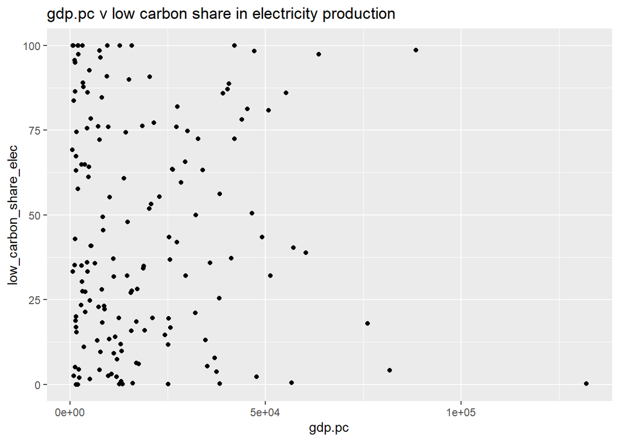

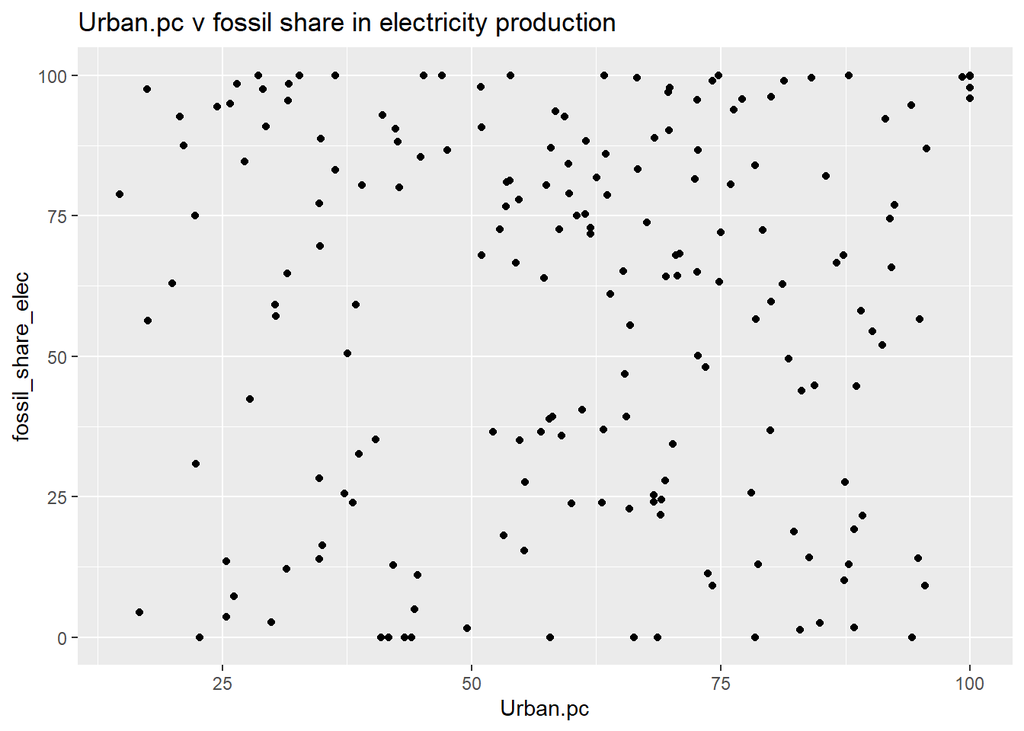

**WarningTask 15: Line plot**

Use the data in `en.data.r` to create the following time-series plots for countries “Germany” (DEU), “China” (CHN) and the “United States” (USA).

- Plot C: Time-series plot for `solar_share_elec`. Different countries should show in differently colored lines.
- Plot D: Time-series plot for `wind_share_elec`. Different countries should show in differently colored lines.

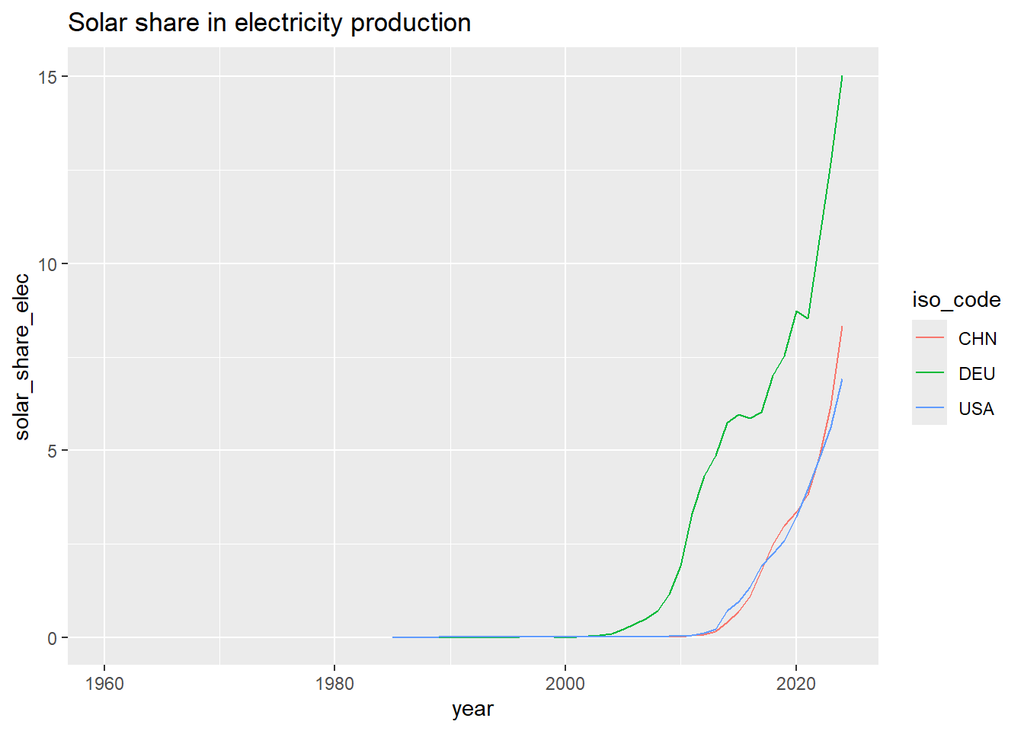

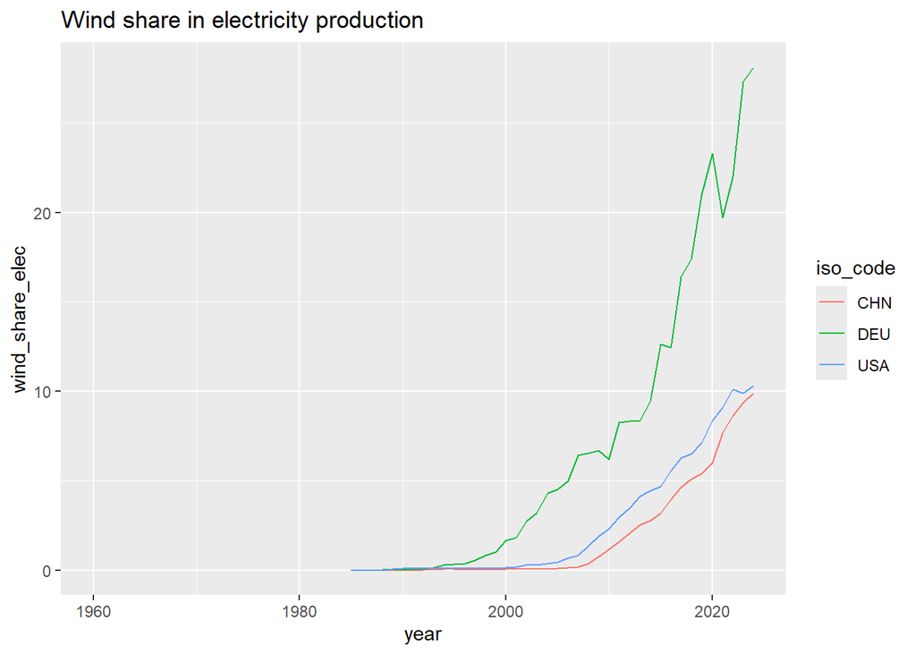

## Preperation for answering the test

You should have the results of your analysis at hand when you answer the test. It is very advisable to also have your code available in case you need to adjust or supplement your code, or just to access the results of your work.